# Subprocess

## 11/17/2022

print view

# Final Project - Due 11:59pm 12/6/2022

Create an assignment, ideally related to your research.

The script resulting from the assignment should be a general purpose tool capable of taking different inputs. You are not required to decompose your assignment into different levels of partial credit (e.g. 70%, 80%, etc.) but you may find it useful to structure it that way for organizational purposes.

You may use any python packages as long as they can be installed with a package manager.

You are required to provide:

- A writeup with sufficient detail for a student to understand and implement the assignment.
- The python code to the solution.
- At least three usage examples
  - commandlines with provided inputs and expected outputs
- An in-class presentation describing the assignment (8-10 minutes)

**Make sure it is okay to publicly release the data.**

### Grading Rubric

##### Presentation

- Is the problem sufficiently motivated?
- Are relevant and informative visual aids used (avoid massive walls of text!)?
- Is the input and desired output clearly described?
- Is there an outline for how the code will work?

##### Writeup

- Is sufficient, but not excessive, background information provided?
- Is the task clearly described?
- Are the steps required to complete the task presented in a logical manner?
- Are there at least three examples, complete with commandline?
- Are the examples sufficient to demonstrate the task?

##### Code

- Does the code do what it is suppose to?
- Are gross inefficiencies avoided?
- Are appropriate data structures used?
- Are language features appropriately used?

# Going Outside the (Python) Box

Sometimes you need to integrate with programs that don't have a python interface (or you think it would just be easier to use the command line interface).

Python has a versatile subprocess module for calling and interacting with other programs.

However, first the venerable system command:

```
  % Total    % Received % Xferd  Average Speed   Time    Time     Time  Current
                                 Dload  Upload   Total   Spent    Left  Speed
100   348  100   348    0     0   4143      0 --:--:-- --:--:-- --:--:--  4192
```

```
0
```

The return value of the system command is the exit code (not what is printed to screen).

```
348
```

# subprocess

The `subprocess` module replaces the following modules (so don't use them):

os.system

os.spawn*

os.popen*

popen2.*

commands.*

# subprocess.call

```
dump
file with spaces
ligs.sdf
ligs.sdf.1
receptor.pdb
receptor.pdb.1
smina
```

```
0
```

Run the command described by `ARGS`. Wait for command to complete, then return the returncode attribute.

[figure not shown]

# ARGS

`ARGS` specifies the command to call and its arguments. It can either be a **string** or a **list of strings**.

```
0
```

```
hello
```

```
0
```

If `shell=False` (default) and `args` is a string, it must be only the name of the program (no arguments). If a list is provided, then the first element is the program name and the remaining elements are the arguments.

# shell

If (and only if) `shell = True` then the string provided for `args` is parsed *exactly* as if you typed it on the commandline. This means you that:

- you must escape special characters (e.g. spaces in file names)
- you can use the wildcard '*' character to expand file names
- you can add IO redirection

If `shell=False` then list arguments must be use and they are passed literally to the program (e.g., it would get '*' for a file name).

`shell` is `False` by default for security reasons. Consider:

```
filename = input("What file would you like to display?\n")
What file would you like to display?
non_existent; rm -rf / #
subprocess.call("cat " + filename, shell=True) # Uh-oh. This will end badly...
```

By default `/bin/sh` is used as the shell. You are probably using `bash`. You can specify what shell to use with the `executable` argument.

```
/bin/sh
/bin/bash
```

```
0
```

# shell Examples

```
ls: cannot access '*': No such file or directory
```

```
2
```

```
dump
file with spaces
ligs.sdf
ligs.sdf.1
receptor.pdb
receptor.pdb.1
smina
0
2
file with spaces
0
file with spaces
0
2
```

```
ls: cannot access 'file': No such file or directory
ls: cannot access 'with': No such file or directory
ls: cannot access 'spaces': No such file or directory
ls: cannot access 'file\ with\ spaces': No such file or directory
```

[output not shown]

# Input/Output/Error

Every process (program) has standard places to write output and read input.

- stdin - standard input is usually from the keyboard
- stdout - standard output is usually buffered
- stderr - standard error is unbuffered (output immediately)

On the commandline, you can changes these places with IO redirection (<,>,|). For example:

```
    grep Congress cnn.html > congress
    wc < congress
    grep Congress cnn.html | wc
```

When calling external programs from scripts we'll usually want to provide input to the programs and read their output, so we'll have to change these 'places' as well.

# stdin/stdout/stderr

stdin, stdout and stderr specify the executed program’s standard input, standard output and standard error file handles, respectively. Valid values are

- `subprocess.PIPE` - this enables communication between your script and the program
- an existing file object - e.g. created with `open`
- None - the program will default to the existing stdin/stdout/stderr

**Do no use `subprocess.PIPE` with subprocess.call**

# Redirecting to files

```
'dump\n'
```

```
2
```

```
ls: cannot access 'nonexistantfile': No such file or directory
```

# subprocess.check_call

`check_call` is identical to `call`, but throws an exception when the called program has a nonzero return value.

```
ls: cannot access 'missingfile': No such file or directory
```

```
---------------------------------------------------------------------------
CalledProcessError                        Traceback (most recent call last)
/tmp/ipykernel_9256/1974956330.py in <module>
----> 1 subprocess.check_call(['ls','missingfile'])

~/apps/anaconda3/lib/python3.9/subprocess.py in check_call(*popenargs, **kwargs)
    371         if cmd is None:
    372             cmd = popenargs[0]
--> 373         raise CalledProcessError(retcode, cmd)
    374     return 0
    375

CalledProcessError: Command '['ls', 'missingfile']' returned non-zero exit status 2.
```

# subprocess.check_output

[figure not shown]

# subprocess.check_output

```
b'dump\nfile with spaces\n'
```

Typically, you are calling a program because you want to parse its output. `check_output` provides the easiest way to do this. It's return value is what was written to `stdout`.

Nonzero return values result in a `CalledProcessError` exception (like `check_call`).

```
b'file with spaces\n'
```

# subprocess.check_output

Can redirect `stderr` to `STDOUT`

```
b"ls: cannot access 'non_existent_file': No such file or directory\n"
```

Why `exit 0`?

```
b'dump\nfile with spaces\nligs.sdf\nligs.sdf.1\nreceptor.pdb\nreceptor.pdb.1\nsmina\n'
```

How can we communicate with the program we are launching?

[figure not shown]

# Popen

All the previous functions are just convenience wrappers around the Popen object.

```
dump
file with spaces
```

```
<Popen: returncode: None args: 'ls'>
```

Popen has quite a few optional arguments. Shown are just the most common.

`cwd` sets the working directory for the process (if `None` defaults to the current working directory of the python script).

`env` is a dictionary that can be used to define a new set of environment variables.

*`Popen` is a constructor and returns a `Popen` object.*

```
subprocess.Popen
```

# Popen

The python script does **not** wait for the called process to finish before returning.

We can finally use `PIPE`.

[figure not shown]

# subprocess.PIPE

If we set stdin/stdout/stderr to `subprocess.PIPE` then they are available to read/write to in the resulting Popen object.

```
_io.BufferedReader
```

```
b'dump\n'
```

# subprocess.PIPE

Pipes enable communication between your script and the called program.

If `stdout/stdin/stderr` is set to `subprocess.PIPE` then that input/output stream of the process is accessible through a file object in the returned object.

```
b'Hello'
```

python3 strings are unicode, but most programs need byte strings

```
---------------------------------------------------------------------------
TypeError                                 Traceback (most recent call last)
/tmp/ipykernel_9256/2142223569.py in <module>
      1 proc = subprocess.Popen('cat',stdin=subprocess.PIPE,stdout=subprocess.PIPE)
----> 2 proc.stdin.write("Hello")
      3 proc.stdin.close()
      4 print(proc.stdout.read())

TypeError: a bytes-like object is required, not 'str'
```

# Unicode (aside)

Bytes strings (which were the default kinds of string in python2) store each character using a single byte (ASCII, like in the Martian).

This allows supports for other languages and the all important emoji.

```
💩
```

Converting bytes to string

```
'a byte str'
```

```
b'a unicode string'
```

# Warning!

*Managing simultaneous input and output is tricky and can easily lead to deadlocks*.

For example, your script may be blocked waiting for output from the process which is blocked waiting for input.

[figure not shown]

# `Popen.communicate(input=None)`

Interact with process: Send data to stdin. Read data from stdout and stderr, until end-of-file is reached. Wait for process to terminate.

`input` is a string of data to be provided to stdin (which must be set to `PIPE`).

Likewise, to receive stdout/stderr, they must be set to `PIPE`.

This *will not deadlock*.

99% of the time if you have to both provide input and read output of a subprocess, communicate will do what you need.

```
x
1
a
```

# Interacting with Popen

- `Popen.poll()` - check to see if process has terminated
- `Popen.wait()` - wait for process to terminate **Do not use PIPE**
- `Popen.terminate()` - terminate the process (ask nicely)
- `Popen.kill()` - kill the process with extreme prejudice

Note that if your are generating a large amount of data, `communicate`, which buffers all the data in memory, may not be an option (instead just read from `Popen.stdout`).

If you need to `PIPE` both `stdin` and `stdout` and can't use `communicate`, be *very* careful about controlling how data is communicated.

# Review

- Just want to run a command?
  - `subprocess.call`
- Want the output of the command?
  - `subprocess.check_output`
- Don't want to wait for command to finish?
  - `subprocess.Popen`
- Need to provide data through stdin?
  - `subprocess.Popen`, `stdin=subprocess.PIPE`, `communicate`

# Exercise

We want to predict the binding affinity of a small molecule to a protein using the program `smina`.

[output not shown]

# Project

1. Run the command `smina -r rec.pdb -l lig.pdb --minimize` on these files. Parse the affinity and RMSD and print them on one line.
2. Run the command `smina -r receptor.pdb -l ligs.sdf --minimize`. Parse the affinities and RMSDS.
   1. Plot histograms of both
   2. Plot a scatter plot

[output not shown]

[output cut: 56 more lines]

```
RMSD: 0.35906
Refine time 0.00858
Affinity: -6.47657  -0.41204 (kcal/mol)
RMSD: 0.04145
Refine time 0.00277
Affinity: -6.58339  -0.62376 (kcal/mol)
RMSD: 0.22803
Refine time 0.00525
Affinity: -6.69025  -0.11960 (kcal/mol)
RMSD: 0.15410
Refine time 0.00368
Affinity: -5.73675  -0.69679 (kcal/mol)
RMSD: 0.06322
Refine time 0.00217
Loop time 0.16327
```

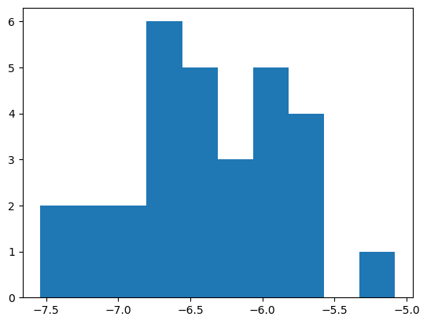

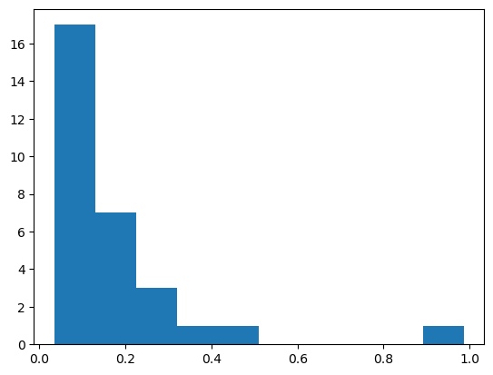

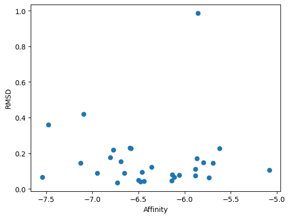